# Mania_Modelling

by_Jasmin_Doenicke

Step7

# STARTER Code

```r
knitr::opts_chunk$set(echo = TRUE)
knitr::opts_knit$set(root.dir = "E:")
```

```r
knitr::opts_chunk$set(error = TRUE)
```

```r
library(tidyverse)
library(naniar)
library(officer)
library(janitor)


#set workind directory
setwd("E:")

#set theme
theme_set(theme_bw())
```

# PHYSICAL HEALTH

## Sleep

```r
sleep <- read_csv("E:/release_5.1/core/physical-health/ph_p_sds.csv")
sleep = subset(sleep, select = c("src_subject_id", "eventname", "sds_p_ss_total", "sds_p_ss_dims",
"sds_p_ss_sbd", "sds_p_ss_da", "sds_p_ss_swtd", "sds_p_ss_does", "sds_p_ss_shy"))

# select only baseline
unique(sleep$eventname)
```

```
## [1] "baseline_year_1_arm_1"    "1_year_follow_up_y_arm_1"
## [3] "2_year_follow_up_y_arm_1" "3_year_follow_up_y_arm_1"
## [5] "4_year_follow_up_y_arm_1"
```

```r
sleep = subset(sleep, sleep$eventname == "baseline_year_1_arm_1")
```

### PLOT Total Sleep Score

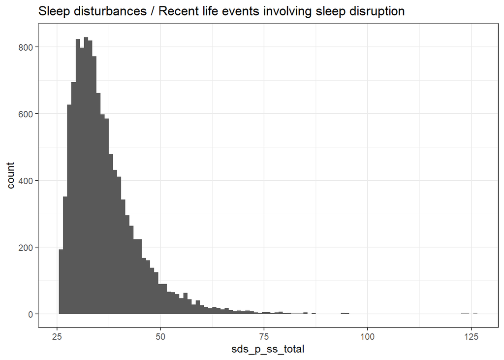

```r
# plot
ggplot(sleep, aes(x = sds_p_ss_total))+
  geom_histogram(binwidth = 1)+
  ggtitle("Sleep disturbances / Recent life events involving sleep disruption")
```

```r
# mean and range
mean(na.omit(sleep$sds_p_ss_total))
```

```
## [1] 36.53781
```

```r
sd(na.omit(sleep$sds_p_ss_total))
```

```
## [1] 8.244489
```

```r
table(sleep$sds_p_ss_total)
```

```
##
##  26  27  28  29  30  31  32  33  34  35  36  37  38  39  40  41  42  43  44  45
## 193 352 627 695 824 798 830 819 772 662 598 586 479 431 411 343 295 264 223 223
##  46  47  48  49  50  51  52  53  54  55  56  57  58  59  60  61  62  63  64  65
## 167 160 138 124  90  89  66  65  59  47  62  43  28  40  25  20  16  20  17  13
##  66  67  68  69  70  71  72  73  74  75  76  77  78  79  80  81  82  83  84  85
##  18  11   7  10   7  10   7   4   3   5   5   2   4   6   2   3   1   1   1   4
##  87  94  95 123 124 126
##   2   3   2   1   1   1
```

### PLOT SDSC - Disorders of Initiating and Maintaining Sleep (DIMS)

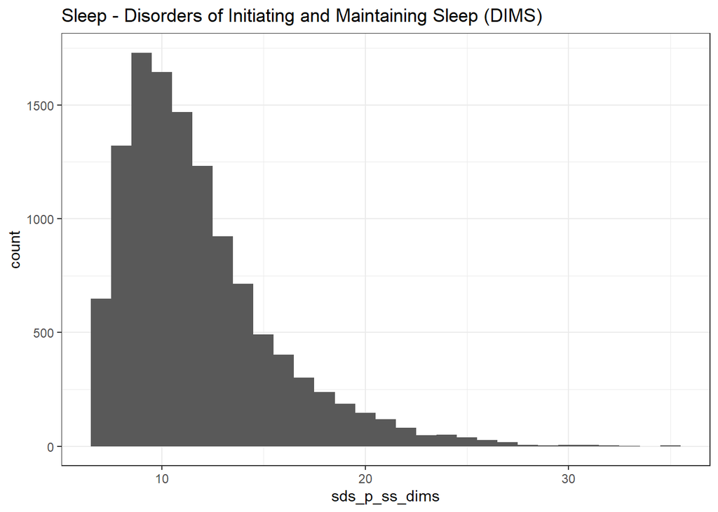

```r
# plot
ggplot(sleep, aes(x = sds_p_ss_dims))+
  geom_histogram(binwidth = 1)+
  ggtitle("Sleep - Disorders of Initiating and Maintaining Sleep (DIMS)")
```

```r
# mean and range
mean(na.omit(sleep$sds_p_ss_dims))
```

```
## [1] 11.7558
```

```r
sd(na.omit(sleep$sds_p_ss_dims))
```

```
## [1] 3.749417
```

```r
table(sleep$sds_p_ss_dims)
```

```
##
##    7    8    9   10   11   12   13   14   15   16   17   18   19   20   21   22
##  649 1321 1730 1645 1468 1233  923  713  492  403  302  239  187  146  119   81
##   23   24   25   26   27   28   29   30   31   32   33   35
##   48   51   38   26   18    6    4    7    7    3    1    3
```

### PLOT SDSC - Sleep Breathing disorders (SBD)

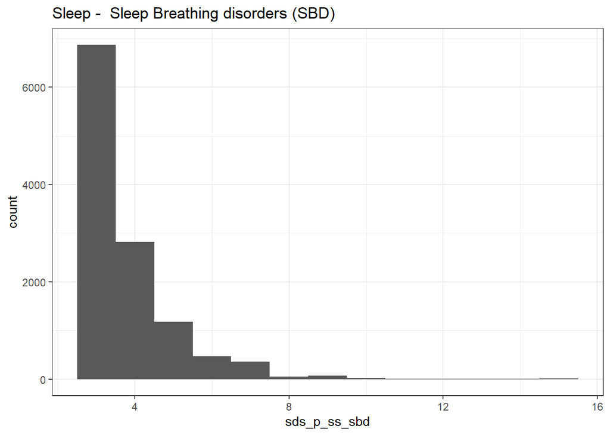

```r
# plot
ggplot(sleep, aes(x = sds_p_ss_sbd))+
  geom_histogram(binwidth = 1)+
  ggtitle("Sleep -  Sleep Breathing disorders (SBD)")
```

```r
# mean and range
mean(na.omit(sleep$sds_p_ss_sbd))
```

```
## [1] 3.772739
```

```r
sd(na.omit(sleep$sds_p_ss_sbd))
```

```
## [1] 1.258098
```

```r
table(sleep$sds_p_ss_sbd)
```

```
##
##    3    4    5    6    7    8    9   10   11   12   13   14   15
## 6872 2813 1176  470  356   52   68   20    8    9    5    3   11
```

### PLOT SDSC - Disorder of Arousal (DA)

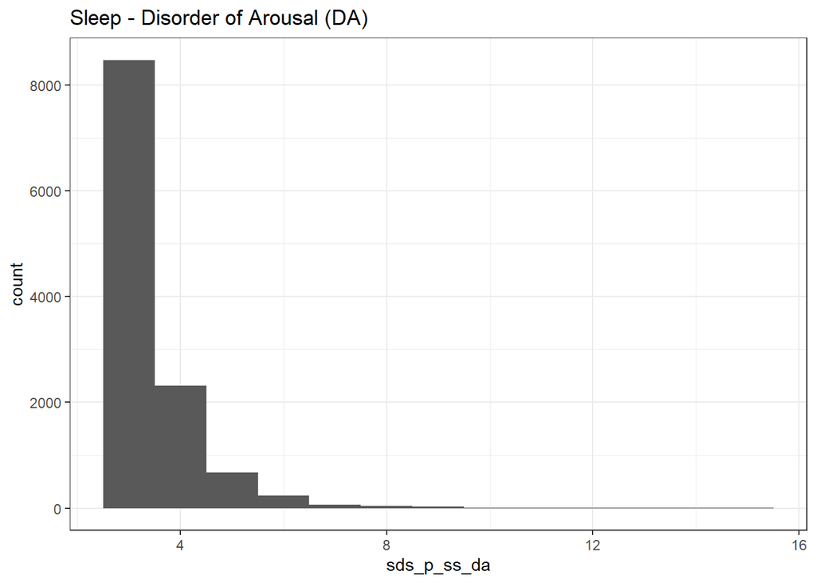

```r
# plot
ggplot(sleep, aes(x = sds_p_ss_da))+
  geom_histogram(binwidth = 1)+
  ggtitle("Sleep - Disorder of Arousal (DA)")
```

```r
# mean and range
mean(na.omit(sleep$sds_p_ss_da))
```

```
## [1] 3.439939
```

```r
sd(na.omit(sleep$sds_p_ss_da))
```

```
## [1] 0.9216004
```

```r
table(sleep$sds_p_ss_da)
```

```
##
##    3    4    5    6    7    8    9   10   11   12   13   14   15
## 8480 2320  673  234   65   40   25    6    2    9    2    2    5
```

### PLOT SDSC - Sleep-Wake transition Disorders (SWTD)

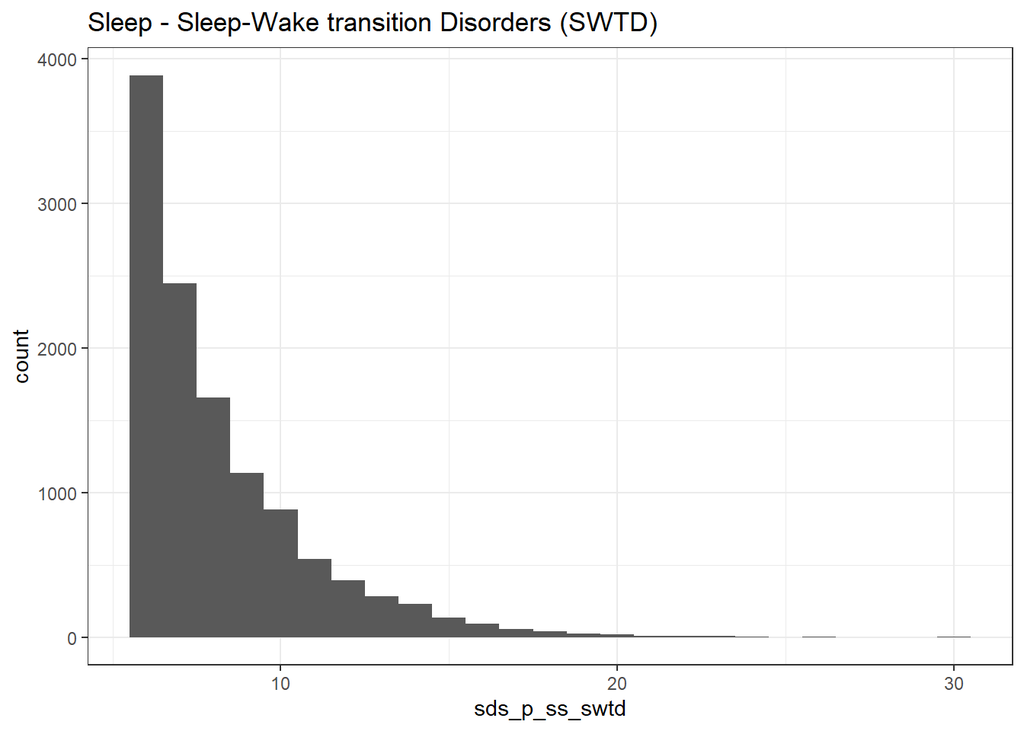

```r
# plot
ggplot(sleep, aes(x = sds_p_ss_swtd))+
  geom_histogram(binwidth = 1)+
  ggtitle("Sleep - Sleep-Wake transition Disorders (SWTD)")
```

```r
# mean and range
mean(na.omit(sleep$sds_p_ss_swtd))
```

```
## [1] 8.18148
```

```r
sd(na.omit(sleep$sds_p_ss_swtd))
```

```
## [1] 2.62834
```

```r
table(sleep$sds_p_ss_swtd)
```

```
##
##    6    7    8    9   10   11   12   13   14   15   16   17   18   19   20   21
## 3884 2444 1654 1135  883  540  393  281  231  132   90   58   40   24   20    8
##   22   23   24   26   30
##    8    6    1    1    3
```

### PLOT SDSC - Disorders of Excessive Somnolence

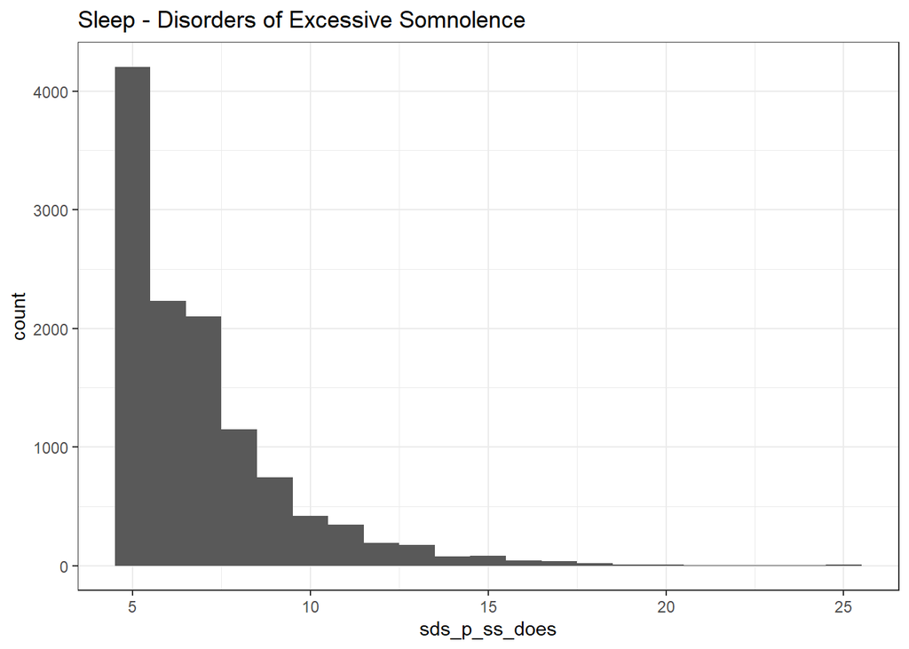

```r
# plot
ggplot(sleep, aes(x = sds_p_ss_does))+
  geom_histogram(binwidth = 1)+
  ggtitle("Sleep - Disorders of Excessive Somnolence")
```

```r
# mean and range
mean(na.omit(sleep$sds_p_ss_does))
```

```
## [1] 6.94925
```

```r
sd(na.omit(sleep$sds_p_ss_does))
```

```
## [1] 2.444622
```

```r
table(sleep$sds_p_ss_does)
```

```
##
##    5    6    7    8    9   10   11   12   13   14   15   16   17   18   19   20
## 4206 2231 2103 1146  746  419  346  191  173   78   84   44   36   18    9    8
##   21   22   23   24   25
##    5    5    5    2    7
```

### PLOT SDSC - Sleep Hyperhydrosis

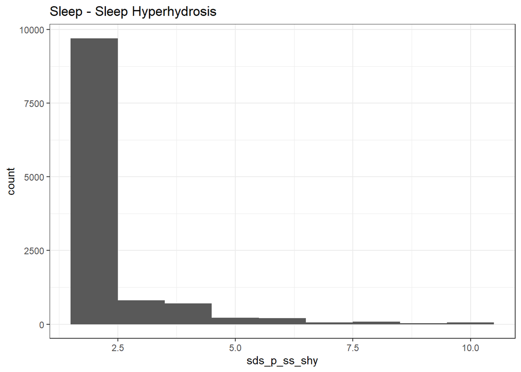

```r
# plot
ggplot(sleep, aes(x = sds_p_ss_shy))+
  geom_histogram(binwidth = 1)+
  ggtitle("Sleep - Sleep Hyperhydrosis")
```

```r
# mean and range
mean(na.omit(sleep$sds_p_ss_shy))
```

```
## [1] 2.438338
```

```r
sd(na.omit(sleep$sds_p_ss_shy))
```

```
## [1] 1.183353
```

```r
table(sleep$sds_p_ss_shy)
```

```
##
##    2    3    4    5    6    7    8    9   10
## 9699  803  699  218  208   60   81   33   62
```

## Irritable Bowel Syndrome

```r
ibs <- read_csv("E:/release_5.1/core/mental-health/mh_p_cbcl.csv")
ibs = subset(ibs, select = c("cbcl_q49_p", "cbcl_q56c_p", "cbcl_q56f_p", "cbcl_q56g_p", "src_subject_id", "eventname")) # select necessary variables only
ibs = subset(ibs, ibs$eventname == "baseline_year_1_arm_1") # select only baseline

# create sum score
ibs$four_sum = ibs$cbcl_q49_p + ibs$cbcl_q56c_p + ibs$cbcl_q56f_p + ibs$cbcl_q56g_p
ibs$three_sum = ibs$cbcl_q56c_p + ibs$cbcl_q56f_p + ibs$cbcl_q56g_p
```

### PLOT 4-item IBS symptoms

This is a version I did not use in the Master’s thesis!

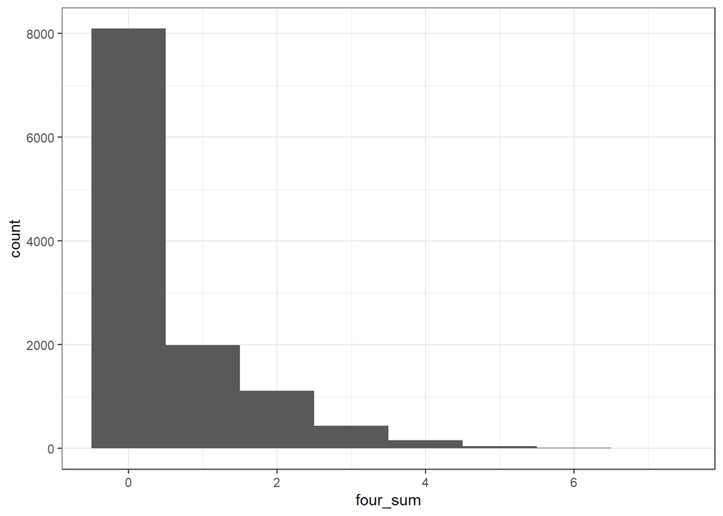

```r
# plot
ggplot(ibs, aes(x = four_sum))+
  geom_histogram(binwidth = 1)
```

```r
# mean and range
mean(na.omit(ibs$four_sum))
```

```
## [1] 0.5523143
```

```r
sd(na.omit(ibs$four_sum))
```

```
## [1] 0.9820818
```

```r
table(ibs$four_sum)
```

```
##
##    0    1    2    3    4    5    6    7
## 8092 1989 1110  441  155   50   19    5
```

### PLOT 3-item IBS symptoms

I usedthese three items for the IBS-score in the analysis, since a previous paper has done the same.

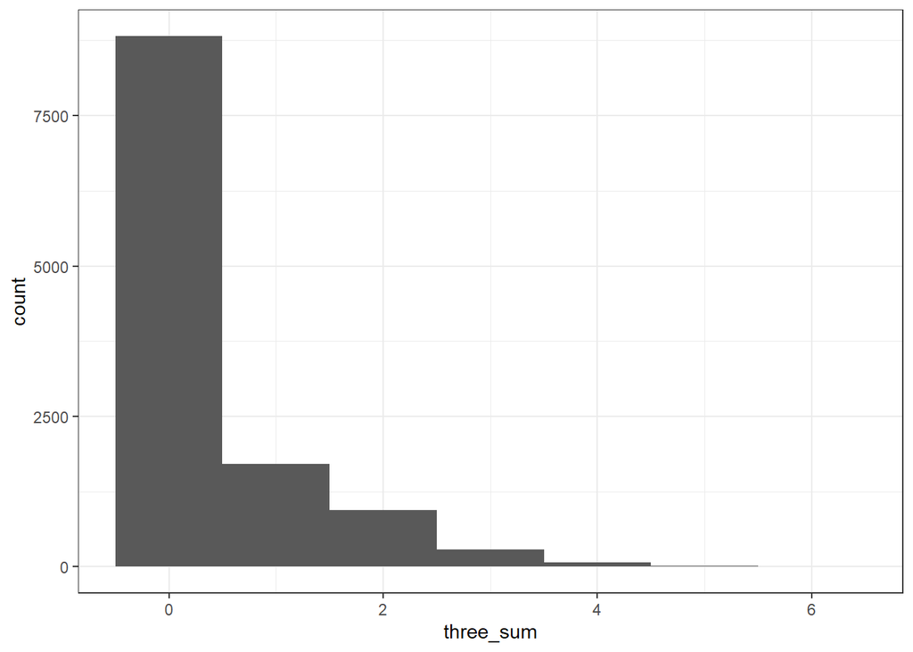

```r
# plot
ggplot(ibs, aes(x = three_sum))+
  geom_histogram(binwidth = 1)
```

```r
# mean and range
mean(na.omit(ibs$three_sum))
```

```
## [1] 0.4115167
```

```r
sd(na.omit(ibs$three_sum))
```

```
## [1] 0.8166886
```

```r
table(ibs$three_sum)
```

```
##
##    0    1    2    3    4    5    6
## 8821 1710  946  290   68   19    7
```

## Asthma

```r
ast <- read_csv("E:/release_5.1/core/physical-health/ph_p_mhx.csv")
asthma = subset(ast, select = c("src_subject_id", "eventname", "medhx_2a"))
asthma = subset(asthma, asthma$eventname == "baseline_year_1_arm_1") # select only baseline (other timepoints are NA anyways)
```

### PLOT Asthma

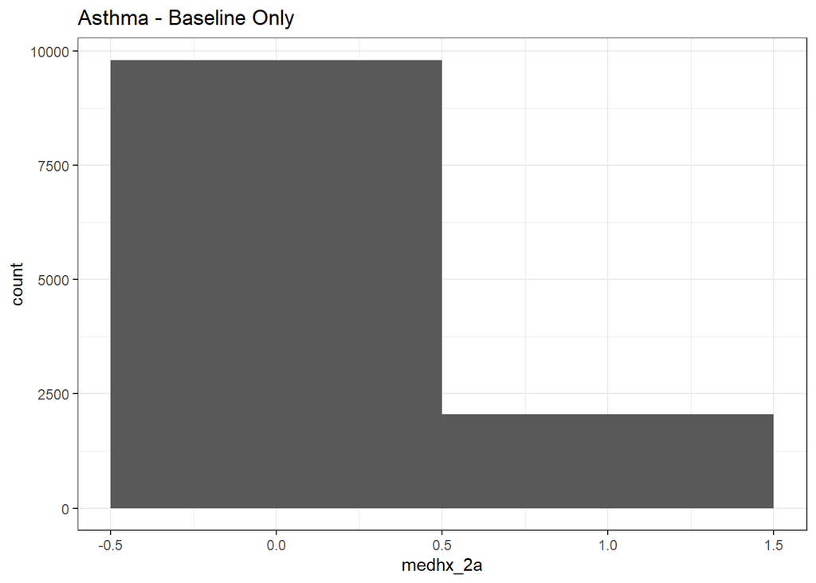

```r
# plot - baseline only
ggplot(asthma, aes(x = medhx_2a))+
  geom_histogram(binwidth = 1) +
  ggtitle("Asthma - Baseline Only")
```

```r
# plot mean and range - baseline only
mean(na.omit(asthma$medhx_2a))
```

```
## [1] 0.1731288
```

```r
sd(na.omit(asthma$medhx_2a))
```

```
## [1] 0.3783745
```

```r
table(asthma$medhx_2a)
```

```
##
##    0    1
## 9810 2054
```

## Obesity

```r
bmi <- read_csv("E:/release_5.1/core/physical-health/ph_y_anthro.csv")

# Calculate mean height and weight across measurements (alternatively: use anthroheightcalc & anthroweightcalc from dataset)
bmi <- bmi %>% mutate(height_mean_in = rowMeans(select(bmi, c(anthro_1_height_in, anthro2heightin, anthro3heightin)), na.rm = TRUE))
bmi <- bmi %>% mutate(weight_mean_lb = rowMeans(select(bmi, c(anthroweight1lb, anthroweight2lb, anthroweight3lb)), na.rm = TRUE))
bmi <- bmi %>% mutate(height_cm = height_mean_in*2.54, weight_kg = weight_mean_lb*0.45359237, height_m = height_cm/100) #conversion to metric


bmi <- bmi %>% mutate(BMI = weight_kg/(height_m^2)) #bmi calculation (kg/m2)
bmi <- bmi %>% replace_with_na(replace = list(BMI = c('NaN'))) #replace NA
bmi$bmiz <- scale(bmi$BMI,center=TRUE, scale=TRUE) #create bmi-z-score
summary(bmi$bmiz) #final bmi z-score.
```

```
##        V1
##  Min.   :-0.4967
##  1st Qu.:-0.0986
##  Median :-0.0469
##  Mean   : 0.0000
##  3rd Qu.: 0.0366
##  Max.   :79.8403
##  NA's   :424
```

```r
bmi = subset(bmi, bmi$eventname == "baseline_year_1_arm_1") # select only baseline
```

### PLOT BMI Full Dataset

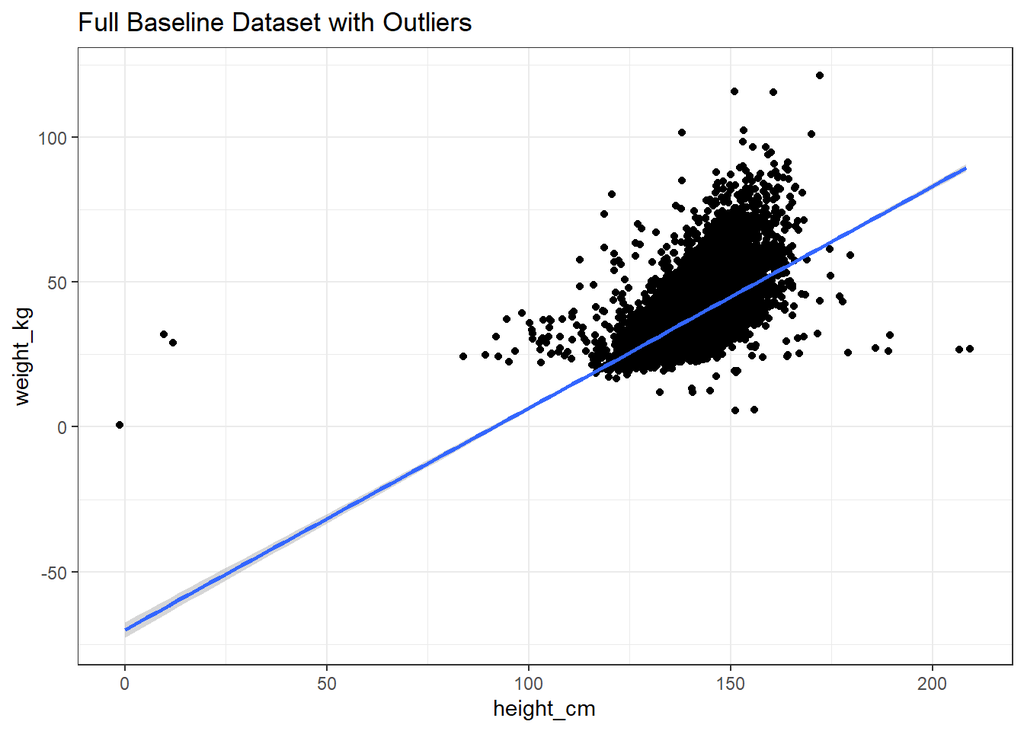

```r
# plotting full dataset (height/cm)
ggplot(bmi, aes(height_cm, weight_kg))+
  geom_jitter(height = 2, width = 2) +
  geom_smooth(method = lm)+
  ggtitle("Full Baseline Dataset with Outliers")
```

```r
# mean and range
mean(na.omit(bmi$BMI))
```

```
## [1] 19.29691
```

```r
min(na.omit(bmi$BMI))
```

```
## [1] 2.07841
```

```r
max(na.omit(bmi$BMI))
```

```
## [1] 3017.34
```

The BMI ranges from 2 to 3017! There seems to be some issues with data quality. Let’s clean it up.

### PLOT BMI: removing +/- 5 z-score

```r
bmi_5 = bmi

# removing outliers
bmi_5<-bmi_5 %>%mutate(bmiz       = if_else(bmiz       < 5,  bmiz,      NA)) # not z-score over 5
bmi_5<-bmi_5 %>%mutate(bmiz       = if_else(bmiz       >-5,  bmiz,      NA)) # no z-score under 5

# remove faulty data without bmiz (it doesnt calculate bmiz and the 4 cases must be removed by hand)
bmi_5<-bmi_5 %>%mutate(BMI        = if_else(BMI        <1000,BMI,       NA)) # remove BMI> 1000
```

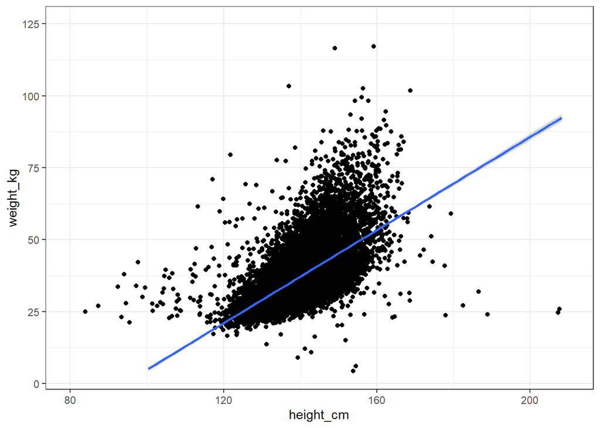

```r
ggplot(bmi_5, aes(height_cm, weight_kg))+
  geom_jitter(height = 2, width = 2) +
  geom_smooth(method = lm)+
  ylim(4, 125)+ # weight
  xlim(80, 210)        # height
```

```r
  ggtitle("Baseline Dataset with +/-5 z-score outliers removed")
```

```
## $title
## [1] "Baseline Dataset with +/-5 z-score outliers removed"
##
## attr(,"class")
## [1] "labels"
```

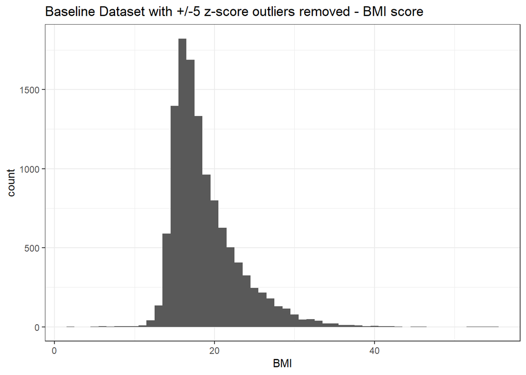

```r
# plotting BMI distribution
ggplot(bmi_5, aes(x = BMI))+
  geom_histogram(binwidth = 1)+
  ggtitle("Baseline Dataset with +/-5 z-score outliers removed - BMI score")
```

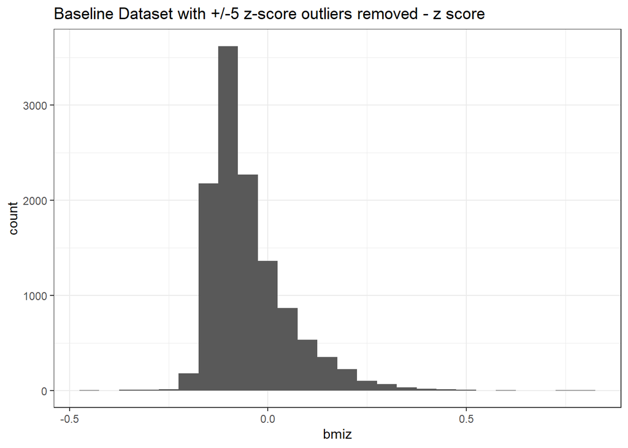

```r
# plotting BMI z-score distribution
ggplot(bmi_5, aes(x = bmiz))+
  geom_histogram(binwidth = 0.05)+
  ggtitle("Baseline Dataset with +/-5 z-score outliers removed - z score")
```

```r
# mean and range - BMI
mean(na.omit(bmi_5$BMI))
```

```
## [1] 18.82562
```

```r
min(na.omit(bmi_5$BMI))
```

```
## [1] 2.07841
```

```r
max(na.omit(bmi_5$BMI))
```

```
## [1] 54.99837
```

```r
# mean and range - weight
mean(na.omit(bmi_5$weight_kg))
```

```
## [1] 37.44511
```

```r
min(na.omit(bmi_5$weight_kg))
```

```
## [1] 0
```

```r
max(na.omit(bmi_5$weight_kg))
```

```
## [1] 123.3771
```

There is still some unclean data, but removing those outliers would require more targeted intervention strategies. Let’s try some.

### PLOT BMI: removing +/- 5 z-score PLUS removing under BMI 12

I did not exclude this data in my Master’s thesis, as the ‘lower limit of human survival’ BMI of 12 is highly debated, and no universally accepted lower BMI thresholds exist, especially for children. Therefore, I retained these values for analysis. However, if you’d like to explore the impact of removing them, here is the code:

```r
# removing more outliers
bmi_5_twelve <-bmi_5 %>%mutate(BMI       = if_else(BMI       >= 12,  BMI,      NA)) # no BMI under 12
```

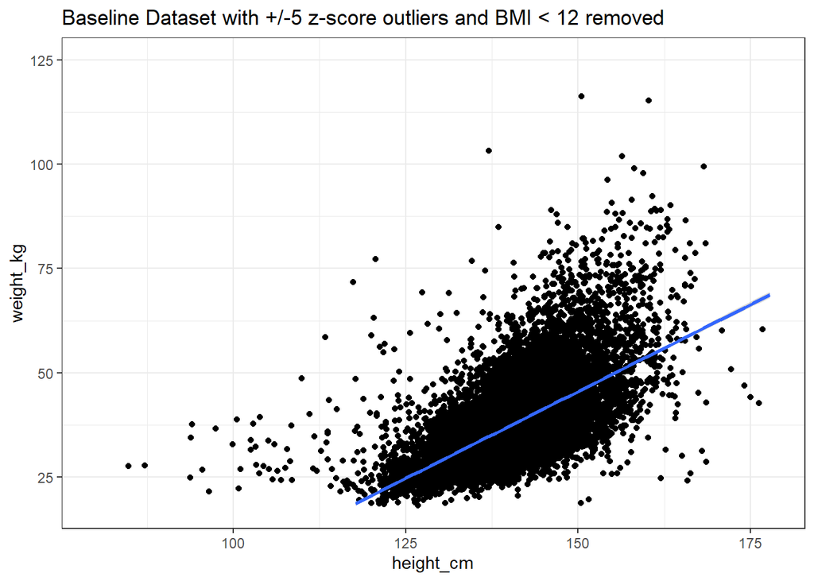

```r
ggplot(bmi_5_twelve, aes(height_cm, weight_kg))+
  geom_jitter(height = 2, width = 2) +
  geom_smooth(method = lm)+
  ylim(18, 125)+ # weight
  xlim(80, 178)+      # height
  ggtitle("Baseline Dataset with +/-5 z-score outliers and BMI < 12 removed")
```

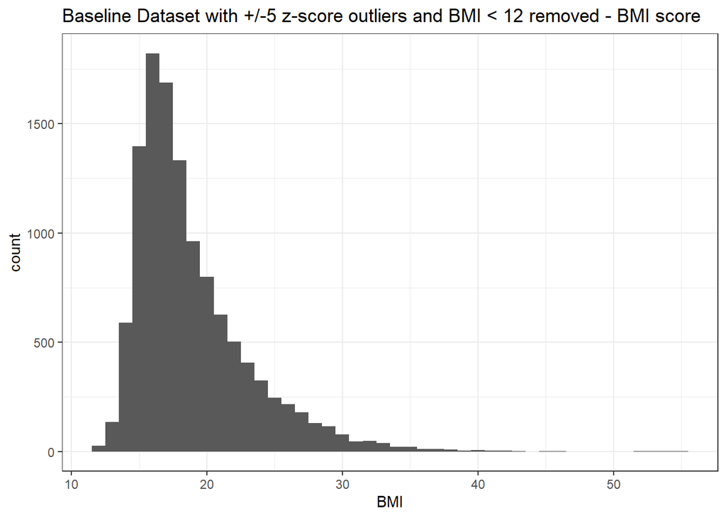

```r
# plotting BMI distribution
ggplot(bmi_5_twelve, aes(x = BMI))+
  geom_histogram(binwidth = 1)+
  ggtitle("Baseline Dataset with +/-5 z-score outliers and BMI < 12 removed - BMI score")
```

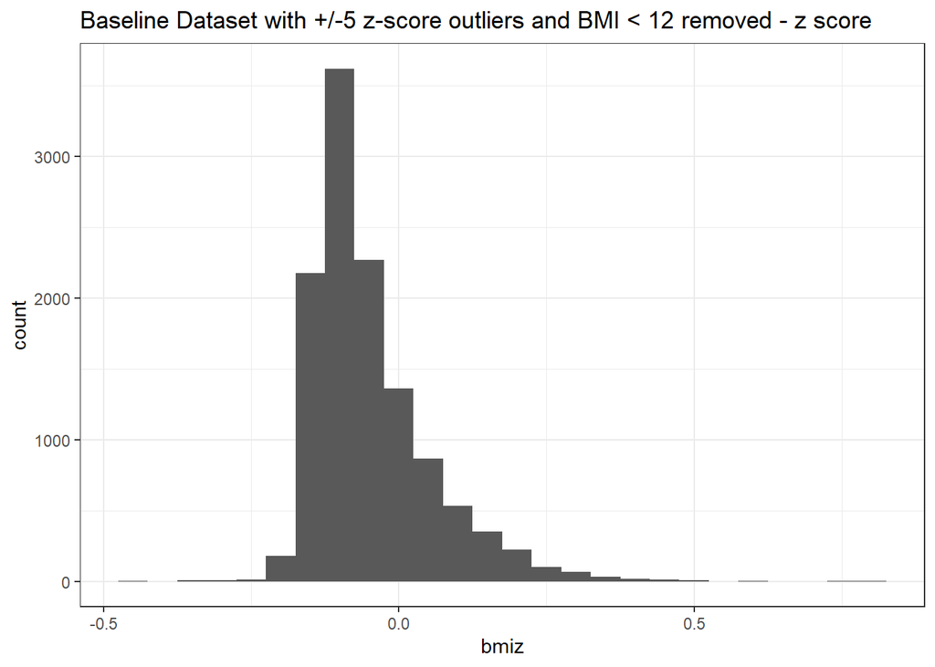

```r
# plotting BMI z-score distribution
ggplot(bmi_5_twelve, aes(x = bmiz))+
  geom_histogram(binwidth = 0.05)+
  ggtitle("Baseline Dataset with +/-5 z-score outliers and BMI < 12 removed - z score")
```

```r
# mean and range - BMI
mean(na.omit(bmi_5_twelve$BMI))
```

```
## [1] 18.86055
```

```r
min(na.omit(bmi_5_twelve$BMI))
```

```
## [1] 12.03108
```

```r
max(na.omit(bmi_5_twelve$BMI))
```

```
## [1] 54.99837
```

```r
# mean and range - Weight
mean(na.omit(bmi_5_twelve$weight_kg))
```

```
## [1] 37.44511
```

```r
min(na.omit(bmi_5_twelve$weight_kg))
```

```
## [1] 0
```

```r
max(na.omit(bmi_5_twelve$weight_kg))
```

```
## [1] 123.3771
```

### PLOT BMI: removing +/- 5 zscores and also all underweight children

This is removing even more children, again an “underweight” BMI changes by age and gender, so this was not used for the analysis and is simply demonstrating different data cleaning options:

```r
# removing more outliers
bmi_5_und <-bmi_5 %>%mutate(BMI       = if_else(BMI       >= 14,  BMI,      NA)) # no BMI under 14
```

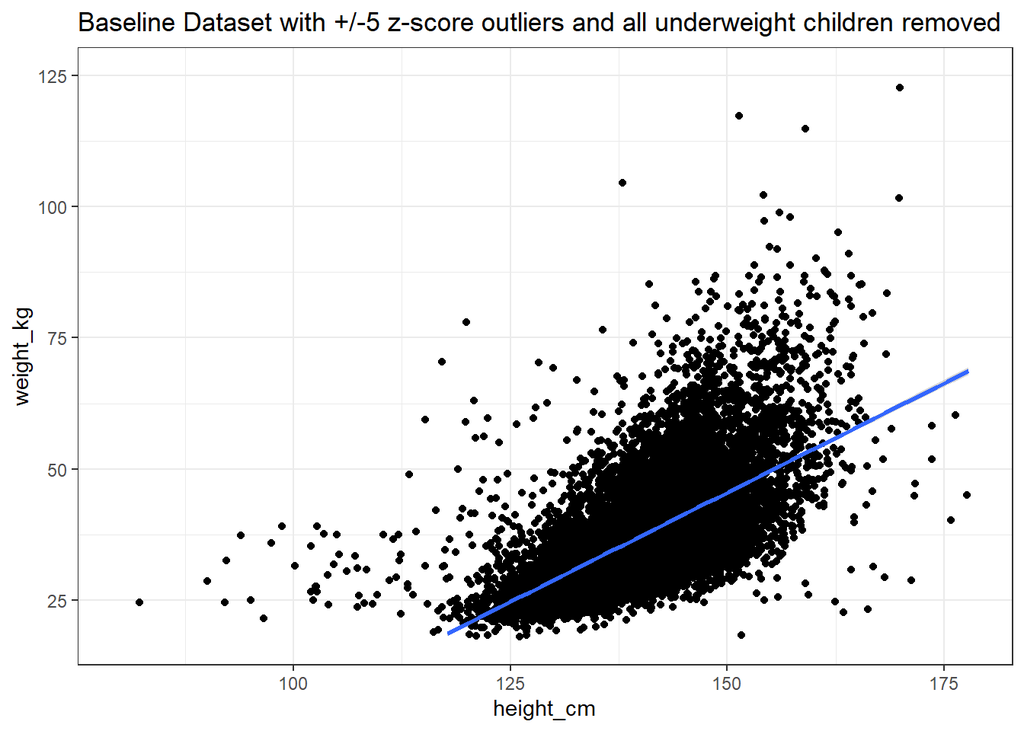

```r
ggplot(bmi_5_und, aes(height_cm, weight_kg))+
  geom_jitter(height = 2, width = 2) +
  geom_smooth(method = lm)+
  ylim(18, 125)+ # weight
  xlim(80, 178)+      # height
  ggtitle("Baseline Dataset with +/-5 z-score outliers and all underweight children removed")
```

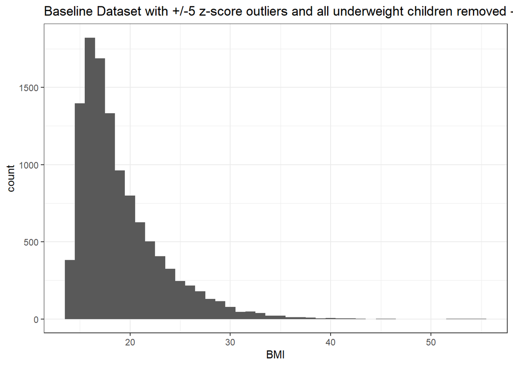

```r
# plotting BMI distribution
ggplot(bmi_5_und, aes(x = BMI))+
  geom_histogram(binwidth = 1)+
  ggtitle("Baseline Dataset with +/-5 z-score outliers and all underweight children removed - BMI score")
```

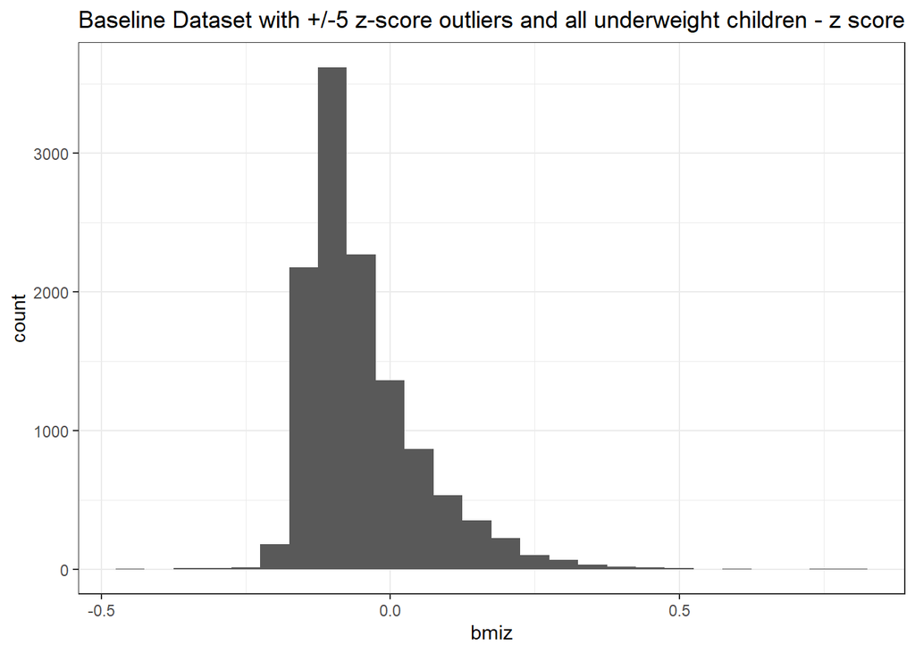

```r
# plotting BMI z-score distribution
ggplot(bmi_5_und, aes(x = bmiz))+
  geom_histogram(binwidth = 0.05)+
  ggtitle("Baseline Dataset with +/-5 z-score outliers and all underweight children - z score")
```

```r
# mean and range - BMI
mean(na.omit(bmi_5_und$BMI))
```

```
## [1] 19.0349
```

```r
min(na.omit(bmi_5_und$BMI))
```

```
## [1] 14.00121
```

```r
max(na.omit(bmi_5_und$BMI))
```

```
## [1] 54.99837
```

```r
# mean and range - Weight
mean(na.omit(bmi_5_und$weight_kg))
```

```
## [1] 37.44511
```

```r
min(na.omit(bmi_5_und$weight_kg))
```

```
## [1] 0
```

```r
max(na.omit(bmi_5_und$weight_kg))
```

```
## [1] 123.3771
```

## Birth/pregnancy complications

pregnancy_cx = total sum of pregnancy complications. pregnancy_binary = (0/1) any pregnancy complications.

obestric_cx = total sum of obstetric complications. obestric_binary = (0/1) any birth complications.

premature_binary = binary, born prematurely. premature_weeks = amount of weeks premature.

csection_binary = (0/1) C-section. smallbirth = (0/1) less than 2,5kg at birth.

For this analysis, categorical variables were used because the reported events occurred 10 years after they happened, making precise recall and continuous data reliability questionable. Categorizing the variables helps mitigate recall bias and ensures a more robust comparison across groups.

```r
baby_data <-read_csv("E:/release_5.1/core/physical-health/ph_p_dhx.csv")
baby_data <- baby_data %>% filter(str_detect(eventname,'baseline')) %>%
  select(src_subject_id,eventname, devhx_10a3_p, devhx_10b3_p, devhx_10c3_p, devhx_10d3_p, devhx_10e3_p, devhx_10f3_p, devhx_10g3_p, devhx_10h3_p, devhx_10i3_p, devhx_10j3_p, devhx_10k3_p, devhx_10l3_p,devhx_10m3_p, devhx_13_3_p, devhx_14a3_p, devhx_14b3_p, devhx_14c3_p, devhx_14d3_p, devhx_14e3_p, devhx_14f3_p, devhx_14g3_p, devhx_14h3_p, birth_weight_lbs, devhx_12a_p, devhx_12_p, devhx_13_3_p)

baby_data<- baby_data %>% replace_with_na_all(condition = ~.x == 999) #remove NA (999)

# Create sum scores
baby_data <- baby_data %>%
  mutate(pregnancy_cx=rowSums(across(c(devhx_10a3_p, devhx_10b3_p, devhx_10c3_p, devhx_10d3_p, devhx_10e3_p, devhx_10f3_p, devhx_10g3_p, devhx_10h3_p, devhx_10i3_p, devhx_10j3_p, devhx_10k3_p, devhx_10l3_p, devhx_10m3_p)),na.rm=T),
         obstetric_cx=rowSums(across(c(devhx_14a3_p, devhx_14b3_p, devhx_14c3_p, devhx_14d3_p, devhx_14e3_p, devhx_14f3_p, devhx_14g3_p, devhx_14h3_p)), na.rm=T),
         pregnancy_binary = if_else(pregnancy_cx>0,1,0),
         obstetric_binary = if_else(obstetric_cx>0,1,0),
         premature_binary = devhx_12a_p,
         premature_weeks = devhx_12_p,
         csection_binary = devhx_13_3_p,
         smallbirth=if_else (birth_weight_lbs < 5.51156, 1, 0)) # 5.51156 lbs = 2.5kg


#only select required variables, remove the rest
baby_data <-baby_data %>% select(src_subject_id, pregnancy_cx, obstetric_cx, pregnancy_binary, obstetric_binary, premature_binary, premature_weeks, csection_binary, smallbirth)
```

### PLOT Pregnancy Complications - Sum Score

Not used in analysis.

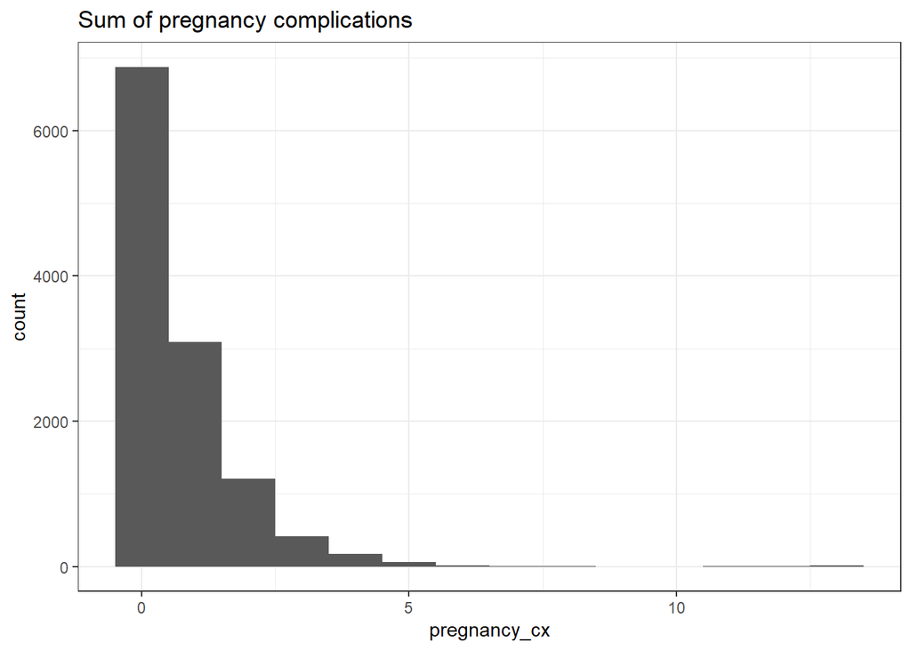

```r
ggplot(baby_data, aes(x = pregnancy_cx))+
  geom_histogram(binwidth = 1)+
  ggtitle("Sum of pregnancy complications")
```

```r
# mean and range
mean(na.omit(baby_data$pregnancy_cx))
```

```
## [1] 0.682343
```

```r
sd(na.omit(baby_data$pregnancy_cx))
```

```
## [1] 1.077327
```

```r
table(baby_data$pregnancy_cx)
```

```
##
##    0    1    2    3    4    5    6    7    8   11   12   13
## 6876 3089 1210  416  176   60   13    9    2    1    2   11
```

### PLOT Pregnancy Complications - Binary

Categorical variables were used in the analysis to reduce recall bias from events reported 10 years later.

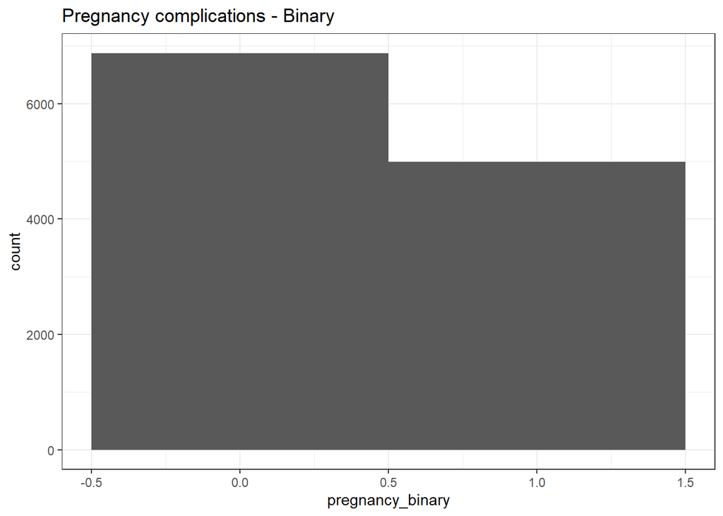

```r
ggplot(baby_data, aes(x = pregnancy_binary))+
  geom_histogram(binwidth = 1)+
  ggtitle("Pregnancy complications - Binary")
```

```r
# mean and range
mean(na.omit(baby_data$pregnancy_binary))
```

```
## [1] 0.4204804
```

```r
sd(na.omit(baby_data$pregnancy_binary))
```

```
## [1] 0.4936569
```

```r
table(baby_data$pregnancy_binary)
```

```
##
##    0    1
## 6876 4989
```

### PLOT Obstetric Complications - Sum Score

Not used in analysis.

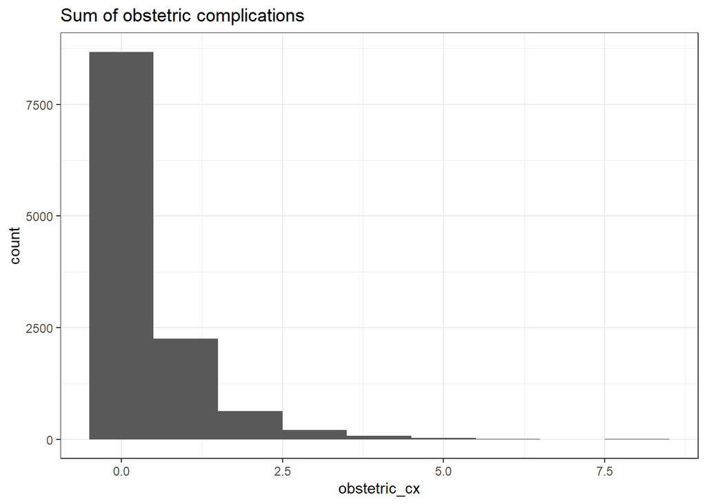

```r
ggplot(baby_data, aes(x = obstetric_cx))+
  geom_histogram(binwidth = 1)+
  ggtitle("Sum of obstetric complications")
```

```r
# mean and range
mean(na.omit(baby_data$obstetric_cx))
```

```
## [1] 0.3884534
```

```r
sd(na.omit(baby_data$obstetric_cx))
```

```
## [1] 0.7738465
```

```r
table(baby_data$obstetric_cx)
```

```
##
##    0    1    2    3    4    5    6    8
## 8675 2247  630  204   74   24    7    4
```

### PLOT Obstetric Complications - Binary

Categorical variables were used in the analysis to reduce recall bias from events reported 10 years later.

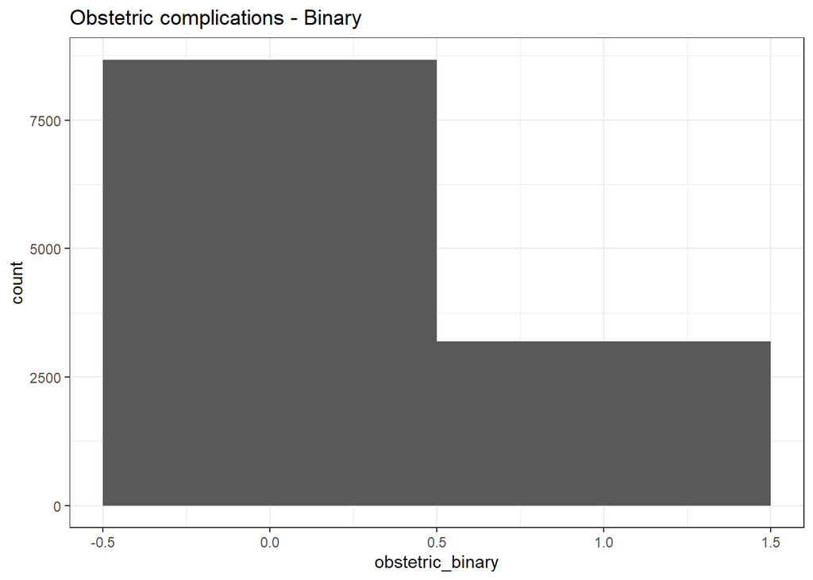

```r
ggplot(baby_data, aes(x = obstetric_binary))+
  geom_histogram(binwidth = 1)+
  ggtitle("Obstetric complications - Binary")
```

```r
# mean and range
mean(na.omit(baby_data$obstetric_binary))
```

```
## [1] 0.268858
```

```r
sd(na.omit(baby_data$obstetric_binary))
```

```
## [1] 0.4433846
```

```r
table(baby_data$obstetric_binary)
```

```
##
##    0    1
## 8675 3190
```

### PLOT Premature birth - in Weeks

Not used in analysis.

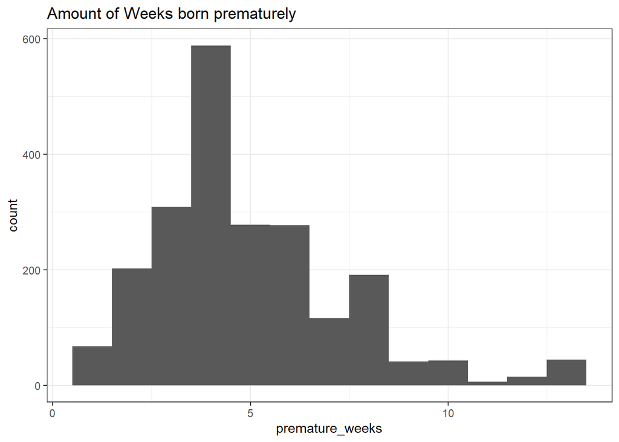

```r
ggplot(baby_data, aes(x = premature_weeks))+
  geom_histogram(binwidth = 1)+
  ggtitle("Amount of Weeks born prematurely")
```

```r
# mean and range
mean(na.omit(baby_data$premature_weeks))
```

```
## [1] 4.942122
```

```r
median(na.omit(baby_data$premature_weeks))
```

```
## [1] 4
```

```r
sd(na.omit(baby_data$premature_weeks))
```

```
## [1] 2.412505
```

```r
table(baby_data$premature_weeks)
```

```
##
##   1   2   3   4   5   6   7   8   9  10  11  12  13
##  67 202 309 588 278 277 116 191  41  43   6  15  44
```

### PLOT Premature birth - Binary

Categorical variables were used in the analysis to reduce recall bias from events reported 10 years later.

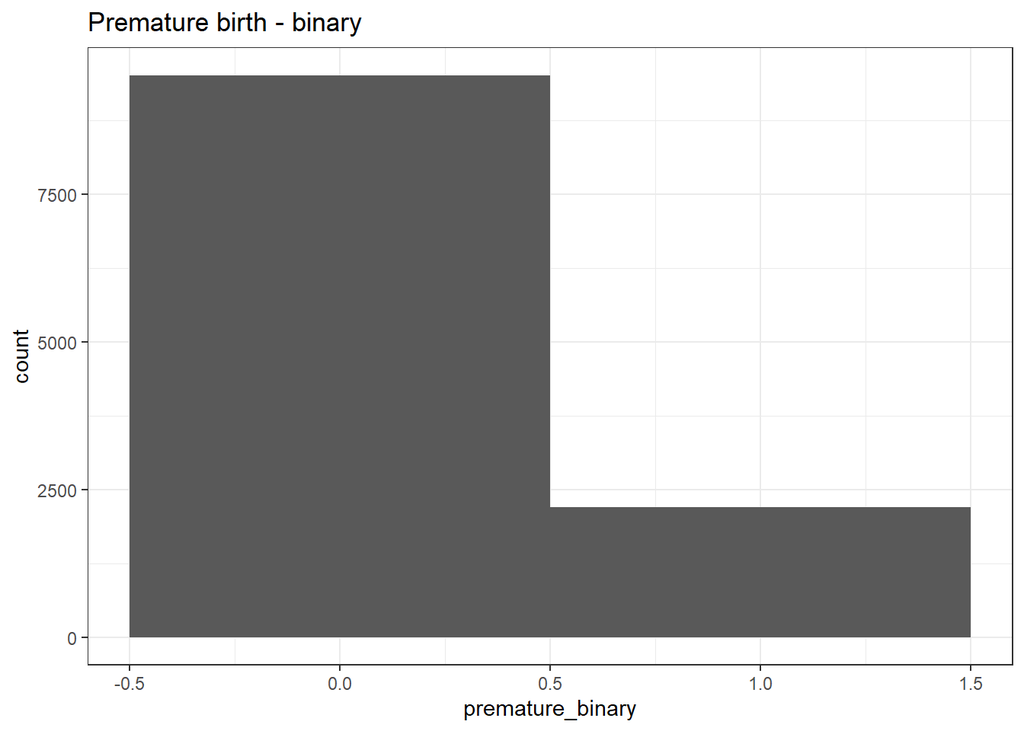

```r
ggplot(baby_data, aes(x = premature_binary))+
  geom_histogram(binwidth = 1)+
  ggtitle("Premature birth - binary")
```

```r
# mean and range
mean(na.omit(baby_data$premature_binary))
```

```
## [1] 0.1880065
```

```r
median(na.omit(baby_data$premature_binary))
```

```
## [1] 0
```

```r
sd(na.omit(baby_data$premature_binary))
```

```
## [1] 0.390734
```

```r
table(baby_data$premature_binary)
```

```
##
##    0    1
## 9519 2204
```

### PLOT Small at birth - Binary

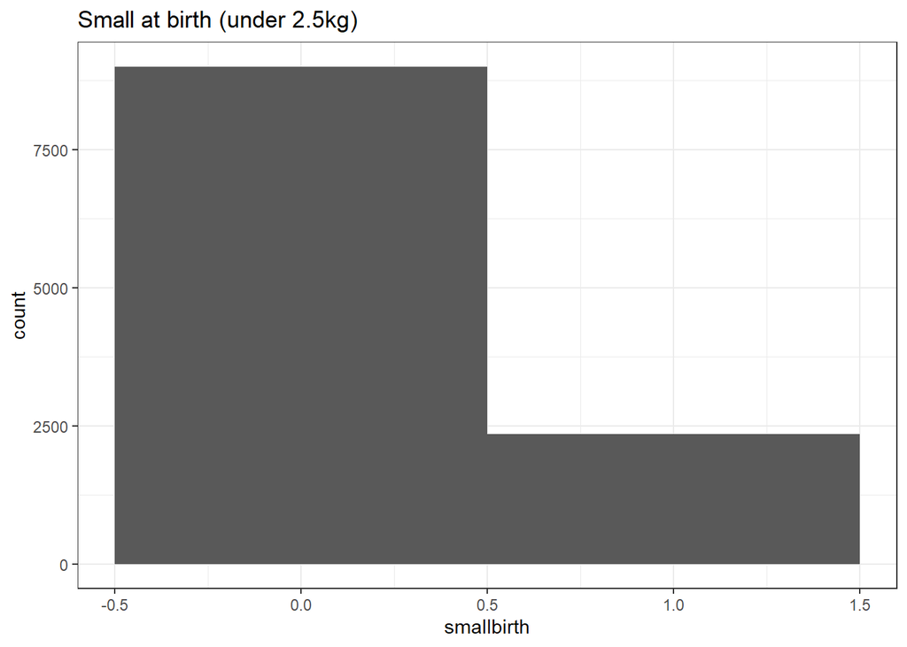

```r
ggplot(baby_data, aes(x = smallbirth))+
  geom_histogram(binwidth = 1)+
  ggtitle("Small at birth (under 2.5kg)")
```

```r
#mean and range
mean(na.omit(baby_data$smallbirth))
```

```
## [1] 0.2071183
```

```r
sd(na.omit(baby_data$smallbirth))
```

```
## [1] 0.4052589
```

```r
table(baby_data$smallbirth)
```

```
##
##    0    1
## 9000 2351
```

### PLOT C-Section - Binary

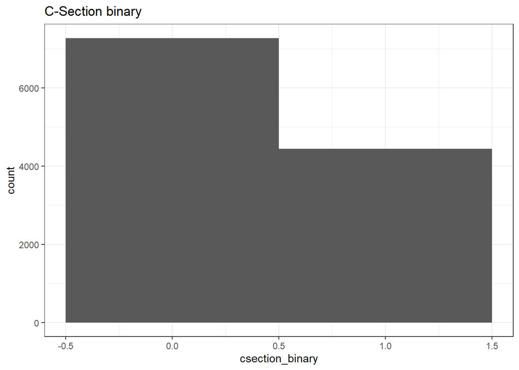

```r
ggplot(baby_data, aes(x = csection_binary))+
  geom_histogram(binwidth = 1)+
  ggtitle("C-Section binary")
```

```r
# mean and range
mean(na.omit(baby_data$csection_binary))
```

```
## [1] 0.3793309
```

```r
sd(na.omit(baby_data$csection_binary))
```

```
## [1] 0.4852413
```

```r
table(baby_data$csection_binary)
```

```
##
##    0    1
## 7273 4445
```

# MENTAL HEALTH

## Depression

```r
depression <- read_csv("E:/release_5.1/core/mental-health/mh_p_cbcl.csv")
depression = subset(depression, select = c("src_subject_id", "eventname", "cbcl_scr_dsm5_depress_t", "cbcl_scr_dsm5_depress_r"))
# Use only baseline
depression = subset(depression, depression$eventname == "baseline_year_1_arm_1")
```

### PLOT Depress CBCL DSM5 Scale t-score

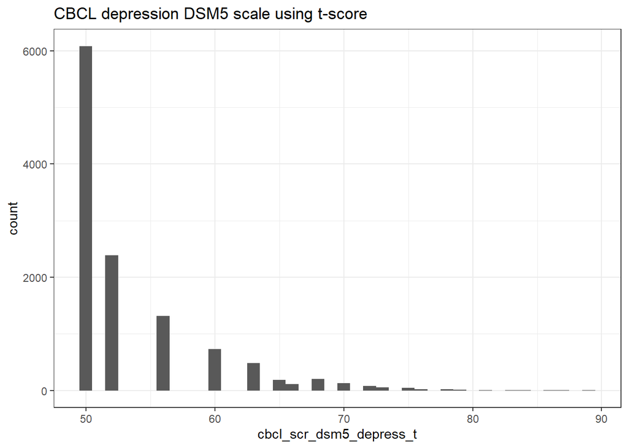

```r
ggplot(depression, aes(x = cbcl_scr_dsm5_depress_t))+
  geom_histogram(binwidth = 1)+
  ggtitle("CBCL depression DSM5 scale using t-score")
```

```r
# mean and range
mean(na.omit(depression$cbcl_scr_dsm5_depress_t))
```

```
## [1] 53.60388
```

```r
sd(na.omit(depression$cbcl_scr_dsm5_depress_t))
```

```
## [1] 5.730277
```

```r
table(depression$cbcl_scr_dsm5_depress_t)
```

```
##
##   50   52   56   60   63   65   66   68   70   72   73   75   76   78   79   81
## 6085 2390 1317  731  480  182  108  201  124   81   53   42   20   19   10    8
##   83   84   86   87   89
##    3    3    1    1    1
```

### PLOT Depress CBCL DSM5 Scale raw-score

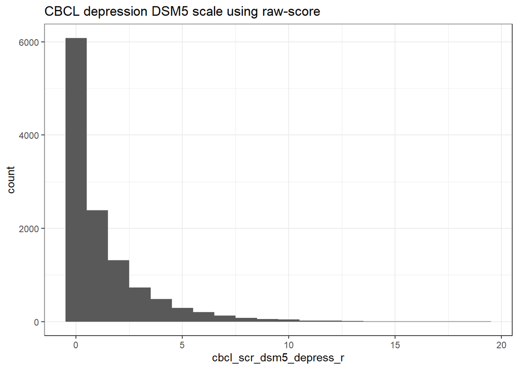

```r
ggplot(depression, aes(x = cbcl_scr_dsm5_depress_r))+
  geom_histogram(binwidth = 1)+
  ggtitle("CBCL depression DSM5 scale using raw-score")
```

```r
# mean and range
mean(na.omit(depression$cbcl_scr_dsm5_depress_r))
```

```
## [1] 1.268381
```

```r
sd(na.omit(depression$cbcl_scr_dsm5_depress_r))
```

```
## [1] 2.009899
```

```r
table(depression$cbcl_scr_dsm5_depress_r)
```

```
##
##    0    1    2    3    4    5    6    7    8    9   10   11   12   13   14   15
## 6085 2390 1317  731  480  290  201  124   81   53   42   20   19   10    8    3
##   16   17   18   19
##    3    1    1    1
```

## Anxiety

```r
anxiety <- read_csv("E:/release_5.1/core/mental-health/mh_p_cbcl.csv")
anxiety = subset(anxiety, select = c("src_subject_id", "eventname", "cbcl_scr_dsm5_anxdisord_t", "cbcl_scr_dsm5_anxdisord_r"))
anxiety = subset(anxiety, anxiety$eventname == "baseline_year_1_arm_1") # select only baseline
```

### PLOT AnxDisord CBCL DSM5 Scale t-score

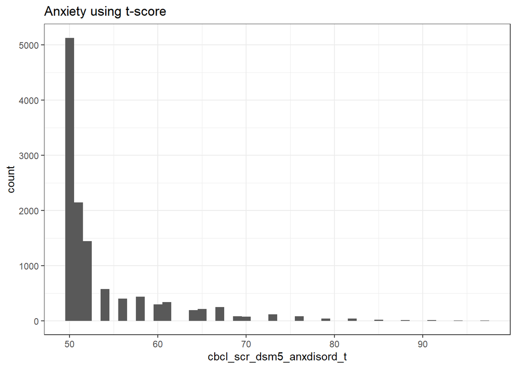

```r
# plot
ggplot(anxiety, aes(x = cbcl_scr_dsm5_anxdisord_t))+
  geom_histogram(binwidth = 1)+
  ggtitle("Anxiety using t-score")
```

```r
# mean and range
mean(na.omit(anxiety$cbcl_scr_dsm5_anxdisord_t))
```

```
## [1] 53.49418
```

```r
sd(na.omit(anxiety$cbcl_scr_dsm5_anxdisord_t))
```

```
## [1] 6.126657
```

```r
table(anxiety$cbcl_scr_dsm5_anxdisord_t)
```

```
##
##   50   51   52   54   56   58   60   61   64   65   67   69   70   73   76   79
## 5126 2145 1441  570  401  434  294  335  189  213  249   79   72  115   79   40
##   82   85   88   91   94   97
##   35   18   12    9    2    2
```

### PLOT AnxDisord CBCL DSM5 raw-score

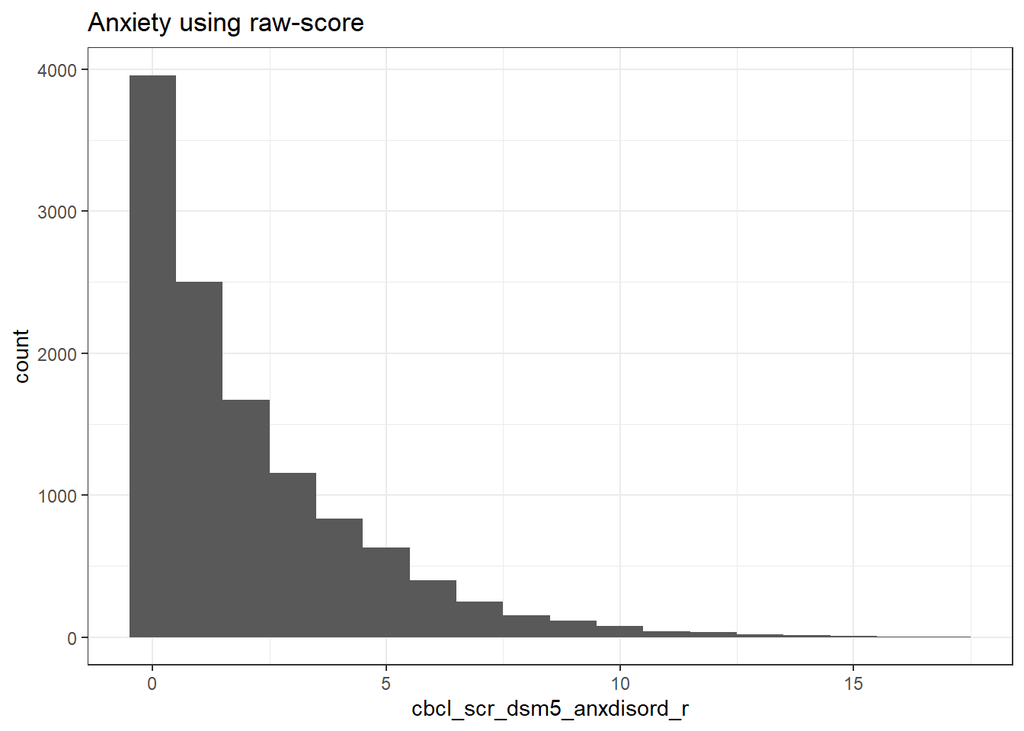

```r
# plot
ggplot(anxiety, aes(x = cbcl_scr_dsm5_anxdisord_r))+
  geom_histogram(binwidth = 1)+
  ggtitle("Anxiety using raw-score")
```

```r
# mean and range
mean(na.omit(anxiety$cbcl_scr_dsm5_anxdisord_r))
```

```
## [1] 2.060708
```

```r
sd(na.omit(anxiety$cbcl_scr_dsm5_anxdisord_r))
```

```
## [1] 2.433573
```

```r
table(anxiety$cbcl_scr_dsm5_anxdisord_r)
```

```
##
##    0    1    2    3    4    5    6    7    8    9   10   11   12   13   14   15
## 3957 2500 1671 1154  835  629  402  249  151  115   79   40   35   18   12    9
##   16   17
##    2    2
```